# popularity and loneliness Study 2b Data Analysis

We use groundhog (https://groundhogr.com/) to manage our packages. Groundhog makes sure that our package versions are consistent with the current date. This way, everyone will be using packages from the same date to prevent any issues related to package versioning in future analyses.

To use groundhog, please: (1) make sure that you have the latest version of R/ RStudio installed; (2) install RTools (3) make sure you are in a new R Session

The R Version used to create this file is: `R version 4.3.0 (2023-04-21 ucrt)`. You can change this out with your own version of R if you are using this template to create your own analysis. If you are reproducing another person’s analysis, please download the version of R used by the previous person to ensure a proper reproduction of the code.

You can identify your version of R by typing `version` into the R Console

You can switch your R version by pressing `Tools` > `Global Options` > `R Version`

[output not shown]

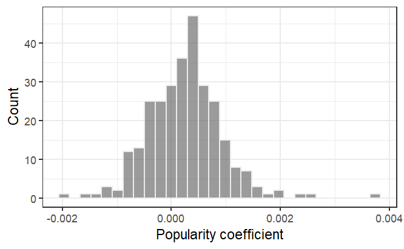

```r
p <- d_coef %>%
  ggplot( aes(x=per_person_kept)) +
    theme_bw()+
    geom_histogram( color="#e9ecef", alpha=0.6, , position="dodge") +
    scale_fill_manual(values=c("#69b3a2", "#404080")) +
    #theme_ipsum() +
    labs(x = "Popularity coefficient", y = "Count") ;p
```

### Descriptives

```r
des = d %>%
  group_by(participant_id)%>%
  slice(1)

# age stats
mean(des$age)
```

```
[1] 42.10764
```

```r
sd(des$age)
```

```
[1] 12.94853
```

```r
range(des$age)
```

```
[1] 21 84
```

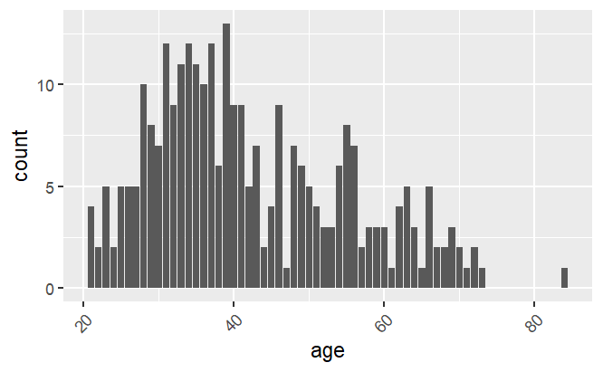

```r
d_age = d %>%
  dplyr::select(participant_id, age, age_cat,gender)
d_age = distinct(d_age)
ggplot(d_age, aes(x = `age`)) +
        geom_bar() +
        theme(axis.text.x = element_text(angle = 45, hjust = 1))
```

```r
# gender stats
table(des$gender)
```

```
female   male
   173    114
```

```r
table(des$race_eth)
```

```
   Asian    Black Hispanic    Other    White
      18       17       19        2      225
```

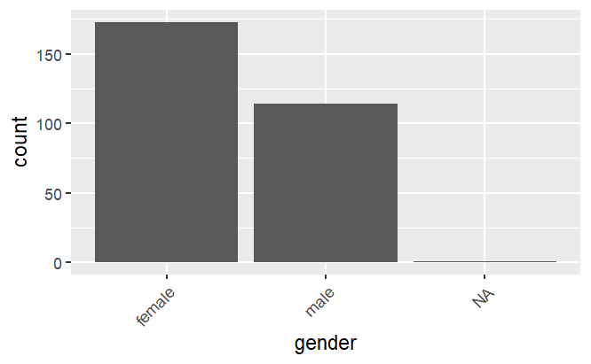

```r
d_gender = d %>%
  dplyr::select(participant_id, age, age_cat,gender)
d_gender = distinct(d_gender)
ggplot(d_gender, aes(x = `gender`)) +
        geom_bar() +
        theme(axis.text.x = element_text(angle = 45, hjust = 1))
```

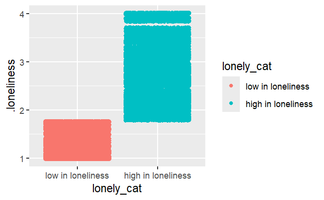

```r
# loneliness stats
ggplot(d, aes(y = .loneliness, color = lonely_cat,
                     fill = lonely_cat, x = lonely_cat)) + geom_point(alpha = 0.3) + geom_jitter()
```

[output not shown]

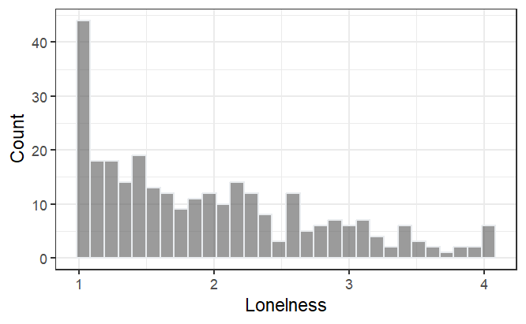

```r
p <- des %>%
  ggplot( aes(x=.loneliness)) +
    theme_bw()+
    geom_histogram( color="#e9ecef", alpha=0.6, , position="dodge") +
    scale_fill_manual(values=c("#69b3a2", "#404080")) +
    #theme_ipsum() +
    labs(x = "Lonelness", y = "Count") ;p
```

```r
median (des$.loneliness)
```

```
[1] 1.775
```

```r
table(des$lonely_cat)
```

```
 low in loneliness high in loneliness
               144                144
```

```r
sd(des$popularity_ratingappealing)
```

```
[1] 1.395127
```

### H1 Analysis (Are lonely individuals more attracted to popular others)

#### homophily

```r
r = lmer(rating_dist ~ kept + (1|participant_id), data = d); summary(r)
```

```
Linear mixed model fit by REML. t-tests use
  Satterthwaite's method [lmerModLmerTest]
Formula:
rating_dist ~ kept + (1 | participant_id)
   Data: d

REML criterion at convergence: 457171.6

Scaled residuals:
    Min      1Q  Median      3Q     Max
-2.6323 -0.7527 -0.1465  0.6380  4.1036

Random effects:
 Groups         Name        Variance Std.Dev.
 participant_id (Intercept)  25.03    5.003
 Residual                   390.32   19.757
Number of obs: 51840, groups:
participant_id, 288

Fixed effects:
              Estimate Std. Error         df
(Intercept)    34.1886     0.3193   334.5796
keptkept      -11.5658     0.1735 51551.0001
            t value Pr(>|t|)
(Intercept)  107.07   <2e-16 ***
keptkept     -66.64   <2e-16 ***
---
Signif. codes:
0 ‘***’ 0.001 ‘**’ 0.01 ‘*’ 0.05 ‘.’ 0.1 ‘ ’ 1

Correlation of Fixed Effects:
         (Intr)
keptkept -0.272
```

```r
# significant - people tend to choose peers who rate artworks more similarly
```

#### homophily & loneliness

```r
r = glmer(kept ~ rating_dist*.loneliness + (1|participant_id), family = "binomial",data = d); summary(r)
```

```
boundary (singular) fit: see help('isSingular')
```

```
Generalized linear mixed model fit by maximum
  likelihood (Laplace Approximation) [glmerMod]
 Family: binomial  ( logit )
Formula:
kept ~ rating_dist * .loneliness + (1 | participant_id)
   Data: d

      AIC       BIC    logLik -2*log(L)
  67829.9   67874.1  -33909.9   67819.9
 df.resid
    51835

Scaled residuals:
    Min      1Q  Median      3Q     Max
-1.5420 -0.9568  0.1589  0.8768  3.0233

Random effects:
 Groups         Name        Variance Std.Dev.
 participant_id (Intercept) 0        0
Number of obs: 51840, groups:
participant_id, 288

Fixed effects:
                          Estimate Std. Error
(Intercept)              0.9559759  0.0404860
rating_dist             -0.0338323  0.0011923
.loneliness             -0.0897788  0.0189472
rating_dist:.loneliness  0.0030435  0.0005552
                        z value Pr(>|z|)
(Intercept)              23.613  < 2e-16 ***
rating_dist             -28.377  < 2e-16 ***
.loneliness              -4.738 2.15e-06 ***
rating_dist:.loneliness   5.482 4.21e-08 ***
---
Signif. codes:
0 ‘***’ 0.001 ‘**’ 0.01 ‘*’ 0.05 ‘.’ 0.1 ‘ ’ 1

Correlation of Fixed Effects:
            (Intr) rtng_d .lnlns
rating_dist -0.810
.loneliness -0.923  0.743
rtng_dst:.l  0.747 -0.921 -0.807
optimizer (Nelder_Mead) convergence code: 0 (OK)
boundary (singular) fit: see help('isSingular')
```

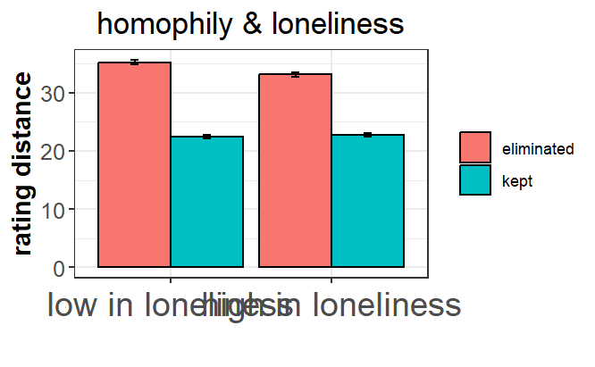

```r
barGraph (d, "rating_dist","lonely_cat","kept","homophily & loneliness", "","rating distance")
```

#### popularity

```r
r = glmer(kept ~ agent_liking + (1|participant_id),family = binomial, data = d); summary(r)
```

```
boundary (singular) fit: see help('isSingular')
```

```
Generalized linear mixed model fit by maximum
  likelihood (Laplace Approximation) [glmerMod]
 Family: binomial  ( logit )
Formula:
kept ~ agent_liking + (1 | participant_id)
   Data: d

      AIC       BIC    logLik -2*log(L)
  71860.9   71887.4  -35927.4   71854.9
 df.resid
    51837

Scaled residuals:
    Min      1Q  Median      3Q     Max
-1.0237 -1.0010  0.0002  0.9990  1.0241

Random effects:
 Groups         Name        Variance Std.Dev.
 participant_id (Intercept) 0        0
Number of obs: 51840, groups:
participant_id, 288

Fixed effects:
               Estimate Std. Error z value
(Intercept)  -5.264e-02  1.838e-02  -2.865
agent_liking  2.487e-04  7.627e-05   3.261
             Pr(>|z|)
(Intercept)   0.00418 **
agent_liking  0.00111 **
---
Signif. codes:
0 ‘***’ 0.001 ‘**’ 0.01 ‘*’ 0.05 ‘.’ 0.1 ‘ ’ 1

Correlation of Fixed Effects:
            (Intr)
agent_likng -0.878
optimizer (Nelder_Mead) convergence code: 0 (OK)
boundary (singular) fit: see help('isSingular')
```

```r
r.squaredGLMM(r)
```

```
                     R2m          R2c
theoretical 0.0002494908 0.0002494908
delta       0.0002052070 0.0002052070
```

```r
confint(r)
```

```
Computing profile confidence intervals ...
```

```
                     2.5 %      97.5 %
.sig01        0.000000e+00  0.01727912
(Intercept)  -8.862071e-02 -0.01663512
agent_liking  9.926199e-05  0.00039824
```

| kept | trial | N | agent_liking | sd | se | ci |
| --- | --- | --- | --- | --- | --- | --- |
| eliminated | 1 | 864 | 204.6759 | 114.9755 | 3.911545 | 7.677255 |
| eliminated | 2 | 864 | 207.3843 | 114.1186 | 3.882392 | 7.620036 |
| eliminated | 3 | 864 | 209.4213 | 116.6097 | 3.967141 | 7.786373 |
| eliminated | 4 | 864 | 204.1204 | 115.8001 | 3.939598 | 7.732315 |
| eliminated | 5 | 864 | 210.3704 | 111.4608 | 3.791972 | 7.442567 |
| eliminated | 6 | 864 | 202.1065 | 118.5220 | 4.032201 | 7.914068 |
| eliminated | 7 | 864 | 208.7269 | 118.4733 | 4.030543 | 7.910814 |
| eliminated | 8 | 864 | 208.6574 | 115.1956 | 3.919036 | 7.691956 |
| eliminated | 9 | 864 | 207.6157 | 113.2389 | 3.852465 | 7.561298 |
| eliminated | 10 | 864 | 215.9259 | 116.8615 | 3.975710 | 7.803192 |

[output cut: 50 more lines]

[output not shown]

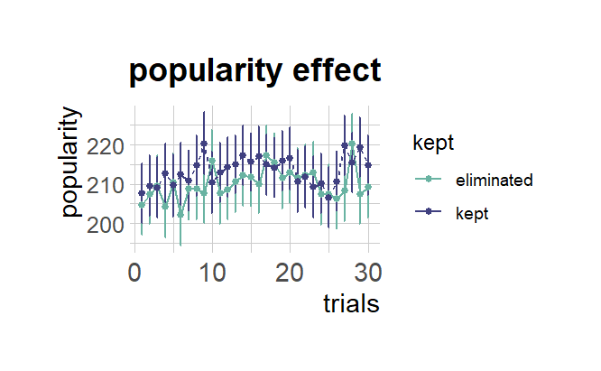

```r
# graph
lineGraph  (d, "agent_liking","kept","trial","popularity effect", "trials","popularity")
```

[figure not shown]

```r
p<-ggplot(data=d, aes(x=kept, y=agent_liking)) +
  geom_bar(stat="identity", fill="steelblue")+
  coord_cartesian(ylim = c(2700000, 2800000)) +
  theme_minimal()
p+ xlab(" ") + ylab("popularity")
```

#### popularity and loneliness (H1)

```r
r = glmer(kept ~ agent_liking*.loneliness + (1|participant_id), family = "binomial",data = d); summary(r)
```

```
boundary (singular) fit: see help('isSingular')
```

```
Generalized linear mixed model fit by maximum
  likelihood (Laplace Approximation) [glmerMod]
 Family: binomial  ( logit )
Formula:
kept ~ agent_liking * .loneliness + (1 | participant_id)
   Data: d

      AIC       BIC    logLik -2*log(L)
  71860.9   71905.1  -35925.4   71850.9
 df.resid
    51835

Scaled residuals:
     Min       1Q   Median       3Q      Max
-1.06086 -1.00040  0.00089  0.99945  1.06287

Random effects:
 Groups         Name        Variance Std.Dev.
 participant_id (Intercept) 0        0
Number of obs: 51840, groups:
participant_id, 288

Fixed effects:
                           Estimate Std. Error
(Intercept)               2.501e-02  4.710e-02
agent_liking             -1.155e-04  1.950e-04
.loneliness              -3.990e-02  2.232e-02
agent_liking:.loneliness  1.868e-04  9.221e-05
                         z value Pr(>|z|)
(Intercept)                0.531   0.5954
agent_liking              -0.592   0.5538
.loneliness               -1.787   0.0739 .
agent_liking:.loneliness   2.026   0.0427 *
---
Signif. codes:
0 ‘***’ 0.001 ‘**’ 0.01 ‘*’ 0.05 ‘.’ 0.1 ‘ ’ 1

Correlation of Fixed Effects:
            (Intr) agnt_l .lnlns
agent_likng -0.875
.loneliness -0.921  0.804
agnt_lkng:.  0.807 -0.920 -0.875
optimizer (Nelder_Mead) convergence code: 0 (OK)
boundary (singular) fit: see help('isSingular')
```

```r
# significant - the more lonely people are, the more they tend to keep popular peers
r.squaredGLMM(r)
```

```
                     R2m          R2c
theoretical 0.0003433879 0.0003433879
delta       0.0002824424 0.0002824424
```

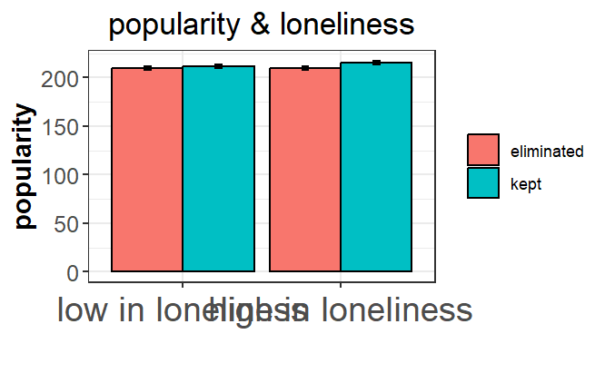

```r
# graph
barGraph  (d, "agent_liking","lonely_cat","kept","popularity & loneliness", "","popularity")
```

| lonely_cat | kept | N | agent_liking | sd | se | ci |
| --- | --- | --- | --- | --- | --- | --- |
| low in loneliness | eliminated | 12960 | 209.9660 | 115.3844 | 1.013549 | 1.986704 |
| low in loneliness | kept | 12960 | 211.3812 | 114.6620 | 1.007203 | 1.974266 |
| high in loneliness | eliminated | 12960 | 209.9892 | 115.3675 | 1.013401 | 1.986414 |
| high in loneliness | kept | 12960 | 215.1744 | 115.2903 | 1.012722 | 1.985083 |

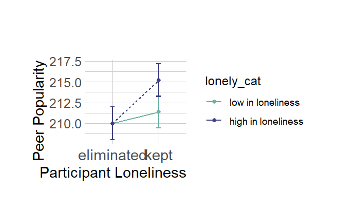

```r
#library(hrbrthemes)
lineGraph (d, "agent_liking","lonely_cat","kept","", "Participant Loneliness","Peer Popularity")
```

### Exploratory Analysis

#### within trial effects

[output not shown]

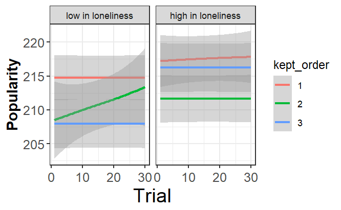

```r
s=d%>%
  filter(kept =="kept")%>%
  #filter(trial <4) %>%
  dplyr::select(participant_id,
         trial,
         agents_names,
         agent_rating,
         kept,
         kept_1_response_liking,
         kept_2_response_liking, kept_3_response_liking,subject_rating, lonely_cat, agent_liking, rating_dist)%>%
  dplyr::group_by(participant_id,trial)%>%
  #mutate(agentNumber = seq(1:3)) %>%
  ungroup()%>%
  dplyr::group_by(participant_id)%>%#, agentNumber)%>%
  arrange(participant_id,trial)


s = s %>%
  #mutate(like_repeat = ifelse(kept_1_response_liking == kept_2_response_liking | kept_1_response_liking == kept_3_response_liking | kept_3_response_liking == kept_2_response_liking, 1,0))%>%
  dplyr::mutate(kept_order = ifelse(agent_liking == kept_1_response_liking, 1, ifelse(agent_liking == kept_2_response_liking, 2,3)))%>%
  dplyr::mutate(kept_order = as.factor(kept_order))

p <- ggplot(s, aes(y = agent_liking, x = trial, color = kept_order)) +
  #geom_point(alpha=0.4) +
  geom_smooth(method='auto')+
  facet_wrap(~lonely_cat)+
    theme_bw()+
    theme(plot.title = element_text(hjust=0.5,size = rel(1.5)),
          axis.title.y = element_text(face="bold",  size=14),
          axis.text.x  = element_text( vjust=0.5, size=12),
          axis.text.y  = element_text( vjust=0.5, size=12),
          axis.title.x = element_text( vjust=0.5, size=18)) +
  xlab("Trial") + ylab("Popularity"); p
```

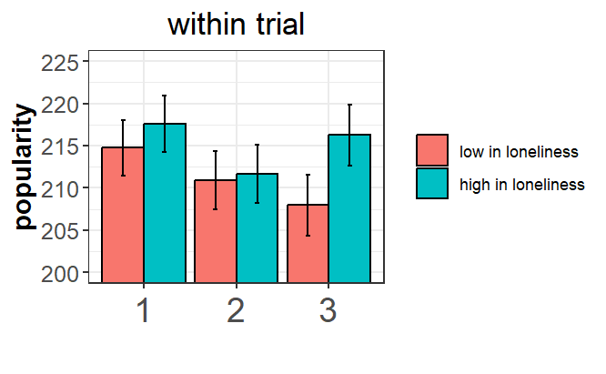

```r
barGraph2(s, "agent_liking","kept_order","lonely_cat","within trial", "","popularity")
```

#### correlation between loneliness and other measures

##### lonelinss & my impression of the agent who has more average likes

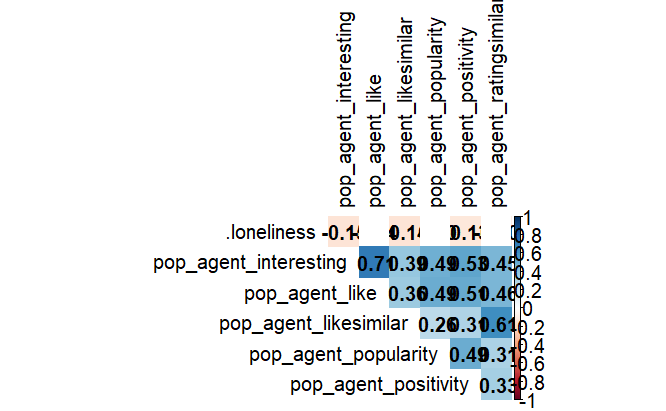

```r
d_moderate = d %>%
  dplyr::select(.loneliness, pop_agent_popularity, pop_agent_positivity, pop_agent_interesting, pop_agent_like, pop_agent_ratingsimilar, pop_agent_likesimilar)
d_moderate = distinct(d_moderate)
d_cor = rcorr(as.matrix(d_moderate), type=c("pearson"))
a = corrplot(d_cor$r, tl.cex = 0.8, order = "alphabet",p.mat=d_cor$P, insig="blank", method = "color", diag = FALSE, type = "upper",number.cex = 0.8,
         addCoef.col = "black", # Add coefficient of correlation
         tl.col="black")  # Text label color and rotation
```

##### lonelinss & my impression of the agent who has less average likes

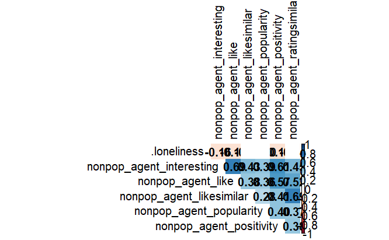

```r
d_moderate = d %>%
  dplyr::select(.loneliness, nonpop_agent_popularity, nonpop_agent_positivity, nonpop_agent_interesting, nonpop_agent_like, nonpop_agent_ratingsimilar, nonpop_agent_likesimilar)
d_moderate = distinct(d_moderate)
d_cor = rcorr(as.matrix(d_moderate), type=c("pearson"))
b = corrplot(d_cor$r, tl.cex = 0.8, order = "alphabet",p.mat=d_cor$P, insig="blank", method = "color", diag = FALSE, type = "upper",number.cex = 0.8,
         addCoef.col = "black", # Add coefficient of correlation
         tl.col="black")  # Text label color and rotation
```

##### loneliness & do I see myself as popular

[figure not shown]

```r
d_moderate = d %>%
  dplyr::select(.loneliness, popularity_selfpopular, popularity_attractpopular, popularity_interetpopular, popularity_wishpopular, popularity_commentpopular, popularity_commentinteresting, popularity_ratingappealing)
d_moderate = distinct(d_moderate)
d_cor = rcorr(as.matrix(d_moderate), type=c("pearson"))
corrplot(d_cor$r, tl.cex = 0.8, order = "alphabet",p.mat=d_cor$P, insig="blank", method = "color", diag = FALSE, type = "upper",number.cex = 0.8,
         addCoef.col = "black", # Add coefficient of correlation
         tl.col="black")  # Text label color and rotation
```

##### attraction to popularity & do I see myself as popular

[figure not shown]

```r
popularity_cor = d %>%
  dplyr::select(popularity_coef, popularity_selfpopular, popularity_attractpopular, popularity_interetpopular, popularity_wishpopular, popularity_commentpopular, popularity_commentinteresting, popularity_ratingappealing)
d_cor = rcorr(as.matrix(popularity_cor), type=c("pearson"))
corrplot(d_cor$r, tl.cex = 0.8, order = "alphabet",p.mat=d_cor$P, insig="blank", method = "color", diag = FALSE, type = "upper",number.cex = 0.8,
         addCoef.col = "black", # Add coefficient of correlation
         tl.col="black")  # Text label color and rotation
```

##### attraction to popularity & my impression of the agent who has more average likes

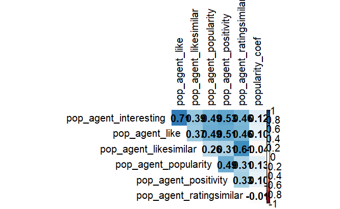

```r
popularity_cor = d %>%
  dplyr::select(popularity_coef, pop_agent_popularity, pop_agent_positivity, pop_agent_interesting, pop_agent_like, pop_agent_ratingsimilar, pop_agent_likesimilar)
d_cor = rcorr(as.matrix(popularity_cor), type=c("pearson"))
corrplot(d_cor$r, tl.cex = 0.8, order = "alphabet",p.mat=d_cor$P, insig="blank", method = "color", diag = FALSE, type = "upper",number.cex = 0.8,
         addCoef.col = "black", # Add coefficient of correlation
         tl.col="black")  # Text label color and rotation
```

##### attraction to popularity & my impression of the agent who has less average likes

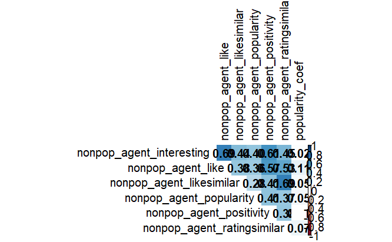

```r
popularity_cor = d %>%
  dplyr::select(popularity_coef, nonpop_agent_popularity, nonpop_agent_positivity, nonpop_agent_interesting, nonpop_agent_like, nonpop_agent_ratingsimilar, nonpop_agent_likesimilar)
d_cor = rcorr(as.matrix(popularity_cor), type=c("pearson"))
corrplot(d_cor$r, tl.cex = 0.8, order = "alphabet",p.mat=d_cor$P, insig="blank", method = "color", diag = FALSE, type = "upper",number.cex = 0.8,
         addCoef.col = "black", # Add coefficient of correlation
         tl.col="black")  # Text label color and rotation
```

##### combined correlation

```r
# general correlation
d_moderate = d %>%
  dplyr::select(.loneliness, popularity_coef, pop_agent_popularity, pop_agent_positivity, pop_agent_interesting, pop_agent_like, pop_agent_ratingsimilar, pop_agent_likesimilar, nonpop_agent_popularity, nonpop_agent_positivity, nonpop_agent_interesting, nonpop_agent_like, nonpop_agent_ratingsimilar, nonpop_agent_likesimilar, popularity_selfpopular, popularity_attractpopular, popularity_interetpopular, popularity_wishpopular, popularity_commentpopular, popularity_commentinteresting, popularity_ratingappealing)
d_moderate = distinct(d_moderate)
d_cor = rcorr(as.matrix(d_moderate), type=c("pearson"))
format_cor = function(cor, p) {
  stars = ifelse(p < 0.001, "***", ifelse(p < 0.01, "**", ifelse(p < 0.05, "*", "")))
  formatted = sprintf("%.2f%s", cor, stars)
  formatted[formatted == "1.00"] = ""  # Remove diagonal
  return(formatted)
}
cor_matrix = matrix(format_cor(d_cor$r, d_cor$P), nrow=21)
colnames(cor_matrix) = rownames(cor_matrix) = colnames(d_moderate)
cor_table = as.data.frame(cor_matrix)
cor_table = cbind(Variable = rownames(cor_table), cor_table)
kable(cor_table, format = "markdown", caption = "Correlation Matrix", align = 'c')
```

Correlation Matrix

|  | Variable | .loneliness | popularity_coef | pop_agent_popularity | pop_agent_positivity | pop_agent_interesting | pop_agent_like | pop_agent_ratingsimilar | pop_agent_likesimilar | nonpop_agent_popularity | nonpop_agent_positivity | nonpop_agent_interesting | nonpop_agent_like | nonpop_agent_ratingsimilar | nonpop_agent_likesimilar | popularity_selfpopular | popularity_attractpopular | popularity_interetpopular | popularity_wishpopular | popularity_commentpopular | popularity_commentinteresting | popularity_ratingappealing |
| --- | --- | --- | --- | --- | --- | --- | --- | --- | --- | --- | --- | --- | --- | --- | --- | --- | --- | --- | --- | --- | --- | --- |
| .loneliness | .loneliness | 1.00NA | 0.09 | 0.00 | -0.13* | -0.15* | -0.04 | -0.10 | -0.14* | -0.10 | -0.16** | -0.16** | -0.15* | -0.04 | -0.01 | -0.28*** | -0.04 | 0.03 | 0.12 | -0.17** | -0.20*** | -0.23*** |
| popularity_coef | popularity_coef | 0.09 | 1.00NA | 0.13* | 0.10 | 0.12* | 0.10 | -0.01 | -0.04 | 0.05 | 0.01 | 0.02 | 0.11 | 0.07 | 0.05 | -0.04 | 0.02 | 0.00 | 0.00 | 0.06 | 0.12* | 0.03 |
| pop_agent_popularity | pop_agent_popularity | 0.00 | 0.13* | 1.00NA | 0.49*** | 0.49*** | 0.49*** | 0.31*** | 0.26*** | 0.20*** | 0.03 | 0.08 | 0.20*** | 0.13* | 0.10 | 0.02 | 0.12* | 0.18** | 0.09 | 0.15* | 0.12* | 0.14* |
| pop_agent_positivity | pop_agent_positivity | -0.13* | 0.10 | 0.49*** | 1.00NA | 0.53*** | 0.51*** | 0.33*** | 0.31*** | 0.08 | -0.03 | 0.13* | 0.11 | 0.05 | 0.01 | 0.12* | 0.14* | 0.12* | 0.08 | 0.16** | 0.17** | 0.20*** |
| pop_agent_interesting | pop_agent_interesting | -0.15* | 0.12* | 0.49*** | 0.53*** | 1.00NA | 0.71*** | 0.46*** | 0.39*** | 0.13* | 0.06 | 0.15** | 0.21*** | 0.07 | -0.02 | 0.16** | 0.20*** | 0.20*** | 0.10 | 0.27*** | 0.22*** | 0.32*** |
| pop_agent_like | pop_agent_like | -0.04 | 0.10 | 0.49*** | 0.51*** | 0.71*** | 1.00NA | 0.46*** | 0.37*** | 0.18** | 0.02 | 0.12* | 0.19** | 0.01 | -0.03 | 0.15* | 0.23*** | 0.22*** | 0.15* | 0.24*** | 0.18** | 0.23*** |
| pop_agent_ratingsimilar | pop_agent_ratingsimilar | -0.10 | -0.01 | 0.31*** | 0.33*** | 0.46*** | 0.46*** | 1.00NA | 0.61*** | 0.19** | 0.09 | 0.14* | 0.12* | 0.12* | -0.03 | 0.21*** | 0.28*** | 0.31*** | 0.28*** | 0.32*** | 0.26*** | 0.35*** |
| pop_agent_likesimilar | pop_agent_likesimilar | -0.14* | -0.04 | 0.26*** | 0.31*** | 0.39*** | 0.37*** | 0.61*** | 1.00NA | 0.21*** | 0.11 | 0.17** | 0.07 | 0.04 | -0.10 | 0.24*** | 0.26*** | 0.25*** | 0.20*** | 0.38*** | 0.32*** | 0.36*** |
| nonpop_agent_popularity | nonpop_agent_popularity | -0.10 | 0.05 | 0.20*** | 0.08 | 0.13* | 0.18** | 0.19** | 0.21*** | 1.00NA | 0.41*** | 0.40*** | 0.36*** | 0.37*** | 0.28*** | 0.14* | 0.13* | 0.07 | -0.00 | 0.10 | 0.10 | 0.09 |
| nonpop_agent_positivity | nonpop_agent_positivity | -0.16** | 0.01 | 0.03 | -0.03 | 0.06 | 0.02 | 0.09 | 0.11 | 0.41*** | 1.00NA | 0.61*** | 0.57*** | 0.38*** | 0.41*** | 0.01 | 0.00 | -0.06 | -0.07 | -0.04 | 0.00 | -0.01 |
| nonpop_agent_interesting | nonpop_agent_interesting | -0.16** | 0.02 | 0.08 | 0.13* | 0.15** | 0.12* | 0.14* | 0.17** | 0.40*** | 0.61*** | 1.00NA | 0.69*** | 0.45*** | 0.44*** | -0.08 | -0.05 | -0.11 | -0.12* | -0.06 | 0.00 | 0.04 |
| nonpop_agent_like | nonpop_agent_like | -0.15* | 0.11 | 0.20*** | 0.11 | 0.21*** | 0.19** | 0.12* | 0.07 | 0.36*** | 0.57*** | 0.69*** | 1.00NA | 0.53*** | 0.38*** | 0.01 | -0.00 | 0.00 | -0.02 | 0.01 | 0.10 | 0.10 |
| nonpop_agent_ratingsimilar | nonpop_agent_ratingsimilar | -0.04 | 0.07 | 0.13* | 0.05 | 0.07 | 0.01 | 0.12* | 0.04 | 0.37*** | 0.38*** | 0.45*** | 0.53*** | 1.00NA | 0.69*** | -0.03 | 0.02 | 0.05 | -0.02 | -0.04 | -0.10 | -0.07 |
| nonpop_agent_likesimilar | nonpop_agent_likesimilar | -0.01 | 0.05 | 0.10 | 0.01 | -0.02 | -0.03 | -0.03 | -0.10 | 0.28*** | 0.41*** | 0.44*** | 0.38*** | 0.69*** | 1.00NA | -0.15** | -0.12* | -0.07 | -0.10 | -0.18** | -0.22*** | -0.19** |
| popularity_selfpopular | popularity_selfpopular | -0.28*** | -0.04 | 0.02 | 0.12* | 0.16** | 0.15* | 0.21*** | 0.24*** | 0.14* | 0.01 | -0.08 | 0.01 | -0.03 | -0.15** | 1.00NA | 0.60*** | 0.51*** | 0.42*** | 0.48*** | 0.44*** | 0.42*** |
| popularity_attractpopular | popularity_attractpopular | -0.04 | 0.02 | 0.12* | 0.14* | 0.20*** | 0.23*** | 0.28*** | 0.26*** | 0.13* | 0.00 | -0.05 | -0.00 | 0.02 | -0.12* | 0.60*** | 1.00NA | 0.78*** | 0.64*** | 0.36*** | 0.33*** | 0.32*** |
| popularity_interetpopular | popularity_interetpopular | 0.03 | 0.00 | 0.18** | 0.12* | 0.20*** | 0.22*** | 0.31*** | 0.25*** | 0.07 | -0.06 | -0.11 | 0.00 | 0.05 | -0.07 | 0.51*** | 0.78*** | 1.00NA | 0.76*** | 0.38*** | 0.32*** | 0.38*** |
| popularity_wishpopular | popularity_wishpopular | 0.12 | 0.00 | 0.09 | 0.08 | 0.10 | 0.15* | 0.28*** | 0.20*** | -0.00 | -0.07 | -0.12* | -0.02 | -0.02 | -0.10 | 0.42*** | 0.64*** | 0.76*** | 1.00NA | 0.32*** | 0.27*** | 0.28*** |
| popularity_commentpopular | popularity_commentpopular | -0.17** | 0.06 | 0.15* | 0.16** | 0.27*** | 0.24*** | 0.32*** | 0.38*** | 0.10 | -0.04 | -0.06 | 0.01 | -0.04 | -0.18** | 0.48*** | 0.36*** | 0.38*** | 0.32*** | 1.00NA | 0.67*** | 0.65*** |
| popularity_commentinteresting | popularity_commentinteresting | -0.20*** | 0.12* | 0.12* | 0.17** | 0.22*** | 0.18** | 0.26*** | 0.32*** | 0.10 | 0.00 | 0.00 | 0.10 | -0.10 | -0.22*** | 0.44*** | 0.33*** | 0.32*** | 0.27*** | 0.67*** | 1.00NA | 0.75*** |
| popularity_ratingappealing | popularity_ratingappealing | -0.23*** | 0.03 | 0.14* | 0.20*** | 0.32*** | 0.23*** | 0.35*** | 0.36*** | 0.09 | -0.01 | 0.04 | 0.10 | -0.07 | -0.19** | 0.42*** | 0.32*** | 0.38*** | 0.28*** | 0.65*** | 0.75*** | 1.00NA |

```r
#write.csv(cor_table, "correlation_table.csv", row.names = FALSE)

means = sapply(d_moderate, mean, na.rm = TRUE)
sds = sapply(d_moderate, sd, na.rm = TRUE)

# Add means and SDs to the correlation table
cor_table = cor_table %>%
  dplyr::mutate(
    Variable = rownames(cor_table),
    Mean = sprintf("%.2f", means),
    SD = sprintf("%.2f", sds)
  ) %>%
  dplyr::select(Variable, Mean, SD, everything())

# Save as CSV
#write.csv(cor_table, "correlation_table_with_means_sds.csv", row.names = FALSE)
```

#### mediation analysis

```r
# List of mediators
mediators <- c(
  "popularity_selfpopular",
  "popularity_commentpopular",
  "popularity_commentinteresting",
  "popularity_wishpopular",
  "pop_agent_ratingsimilar",
  "pop_agent_likesimilar"
)
med_model <- lm(popularity_selfpopular ~ .loneliness, data = d)
# Fit the outcome model
out_model <- lm(popularity_coef ~ .loneliness + popularity_selfpopular, data = d)
# Run the mediation analysis with bootstrapping
med_result <- mediate(med_model, out_model, treat = ".loneliness", mediator = "popularity_selfpopular", boot = TRUE, sims = 5000)
```

```
Running nonparametric bootstrap
```

```r
summary(med_result)
```

```
Causal Mediation Analysis

Nonparametric Bootstrap Confidence Intervals with the Percentile Method

               Estimate 95% CI Lower
ACME           3.74e-06     1.42e-06
ADE            6.84e-05     5.91e-05
Total Effect   7.21e-05     6.39e-05
Prop. Mediated 5.19e-02     1.83e-02
               95% CI Upper p-value
ACME                   0.00   8e-04 ***
ADE                    0.00  <2e-16 ***
Total Effect           0.00  <2e-16 ***
Prop. Mediated         0.09   8e-04 ***
---
Signif. codes:
0 ‘***’ 0.001 ‘**’ 0.01 ‘*’ 0.05 ‘.’ 0.1 ‘ ’ 1

Sample Size Used: 51840


Simulations: 5000
```

```r
med_model <- lm(pop_agent_ratingsimilar ~ .loneliness, data = d)
# Fit the outcome model
out_model <- lm(popularity_coef ~ .loneliness + pop_agent_ratingsimilar, data = d)
# Run the mediation analysis with bootstrapping
med_result <- mediate(med_model, out_model, treat = ".loneliness", mediator = "pop_agent_ratingsimilar", boot = TRUE, sims = 5000)
```

```
Running nonparametric bootstrap
```

```r
summary(med_result)
```

```
Causal Mediation Analysis

Nonparametric Bootstrap Confidence Intervals with the Percentile Method

                Estimate 95% CI Lower
ACME            3.49e-07    -3.61e-07
ADE             7.18e-05     6.36e-05
Total Effect    7.21e-05     6.41e-05
Prop. Mediated  4.84e-03    -5.01e-03
               95% CI Upper p-value
ACME                   0.00    0.33
ADE                    0.00  <2e-16 ***
Total Effect           0.00  <2e-16 ***
Prop. Mediated         0.01    0.33
---
Signif. codes:
0 ‘***’ 0.001 ‘**’ 0.01 ‘*’ 0.05 ‘.’ 0.1 ‘ ’ 1

Sample Size Used: 51840


Simulations: 5000
```

```r
med_model <- lm(pop_agent_likesimilar ~ .loneliness, data = d)
# Fit the outcome model
out_model <- lm(popularity_coef ~ .loneliness + pop_agent_likesimilar, data = d)
# Run the mediation analysis with bootstrapping
med_result <- mediate(med_model, out_model, treat = ".loneliness", mediator = "pop_agent_likesimilar", boot = TRUE, sims = 5000)
```

```
Running nonparametric bootstrap
```

```r
summary(med_result)
```

```
Causal Mediation Analysis

Nonparametric Bootstrap Confidence Intervals with the Percentile Method

               Estimate 95% CI Lower
ACME           3.00e-06     1.88e-06
ADE            6.91e-05     6.08e-05
Total Effect   7.21e-05     6.42e-05
Prop. Mediated 4.17e-02     2.48e-02
               95% CI Upper p-value
ACME                   0.00  <2e-16 ***
ADE                    0.00  <2e-16 ***
Total Effect           0.00  <2e-16 ***
Prop. Mediated         0.06  <2e-16 ***
---
Signif. codes:
0 ‘***’ 0.001 ‘**’ 0.01 ‘*’ 0.05 ‘.’ 0.1 ‘ ’ 1

Sample Size Used: 51840


Simulations: 5000
```

```r
med_model <- lm(nonpop_agent_ratingsimilar ~ .loneliness, data = d)
# Fit the outcome model
out_model <- lm(popularity_coef ~ .loneliness + nonpop_agent_ratingsimilar, data = d)
# Run the mediation analysis with bootstrapping
med_result <- mediate(med_model, out_model, treat = ".loneliness", mediator = "nonpop_agent_ratingsimilar", boot = TRUE, sims = 5000)
```

```
Running nonparametric bootstrap
```

```r
summary(med_result)
```

```
Causal Mediation Analysis

Nonparametric Bootstrap Confidence Intervals with the Percentile Method

                Estimate 95% CI Lower
ACME           -2.38e-06    -2.99e-06
ADE             7.45e-05     6.66e-05
Total Effect    7.21e-05     6.41e-05
Prop. Mediated -3.30e-02    -4.29e-02
               95% CI Upper p-value
ACME                   0.00  <2e-16 ***
ADE                    0.00  <2e-16 ***
Total Effect           0.00  <2e-16 ***
Prop. Mediated        -0.02  <2e-16 ***
---
Signif. codes:
0 ‘***’ 0.001 ‘**’ 0.01 ‘*’ 0.05 ‘.’ 0.1 ‘ ’ 1

Sample Size Used: 51840


Simulations: 5000
```

```r
med_model <- lm(nonpop_agent_likesimilar ~ .loneliness, data = d)
# Fit the outcome model
out_model <- lm(popularity_coef ~ .loneliness + nonpop_agent_likesimilar, data = d)
# Run the mediation analysis with bootstrapping
med_result <- mediate(med_model, out_model, treat = ".loneliness", mediator = "nonpop_agent_likesimilar", boot = TRUE, sims = 5000)
```

```
Running nonparametric bootstrap
```

```r
summary(med_result)
```

```
Causal Mediation Analysis

Nonparametric Bootstrap Confidence Intervals with the Percentile Method

                Estimate 95% CI Lower
ACME           -2.04e-07    -5.74e-07
ADE             7.23e-05     6.41e-05
Total Effect    7.21e-05     6.39e-05
Prop. Mediated -2.83e-03    -7.98e-03
               95% CI Upper p-value
ACME                      0    0.25
ADE                       0  <2e-16 ***
Total Effect              0  <2e-16 ***
Prop. Mediated            0    0.25
---
Signif. codes:
0 ‘***’ 0.001 ‘**’ 0.01 ‘*’ 0.05 ‘.’ 0.1 ‘ ’ 1

Sample Size Used: 51840


Simulations: 5000
```

```r
med_model <- lm(popularity_wishpopular ~ .loneliness, data = d)
# Fit the outcome model
out_model <- lm(popularity_coef ~ .loneliness + popularity_wishpopular, data = d)
# Run the mediation analysis with bootstrapping
med_result <- mediate(med_model, out_model, treat = ".loneliness", mediator = "popularity_wishpopular", boot = TRUE, sims = 5000)
```

```
Running nonparametric bootstrap
```

```r
summary(med_result)
```

```
Causal Mediation Analysis

Nonparametric Bootstrap Confidence Intervals with the Percentile Method

                Estimate 95% CI Lower
ACME           -8.85e-07    -1.72e-06
ADE             7.30e-05     6.48e-05
Total Effect    7.21e-05     6.39e-05
Prop. Mediated -1.23e-02    -2.43e-02
               95% CI Upper p-value
ACME                      0   0.028 *
ADE                       0  <2e-16 ***
Total Effect              0  <2e-16 ***
Prop. Mediated            0   0.028 *
---
Signif. codes:
0 ‘***’ 0.001 ‘**’ 0.01 ‘*’ 0.05 ‘.’ 0.1 ‘ ’ 1

Sample Size Used: 51840


Simulations: 5000
```